# New York City flights

## Other insights?

### What is the most popular Aircraft Manufacturer?

Transform data to merge manufacture variants

```
dat2 <- dat
dat2 [which(dat $plane_manufacturer == "AIRBUS INDUSTRIE"),] $plane_manufacturer <- "AIRBUS"
dat2 [which(dat $plane_manufacturer == "CANADAIR LTD"),] $plane_manufacturer <- "CANADAIR"
dat2 [which(dat $plane_manufacturer %in% c("MCDONNELL DOUGLAS AIRCRAFT CO",
                                            "MCDONNELL DOUGLAS CORPORATION")),] $plane_manufacturer <- "MCDONNELL DOUGLAS"
```

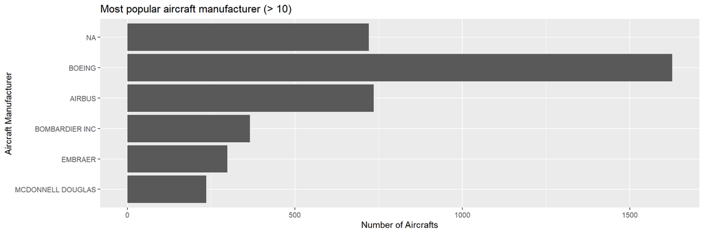

```
dat2 %>%
  group_by(plane_manufacturer) %>%
  distinct(tailnum) %>%
  count(plane_manufacturer, sort = TRUE) %>%
  filter(n > 10) %>%
  ggplot() +
  geom_col(aes(reorder(plane_manufacturer, n), n)) +
  coord_flip() +
  labs(
    title = "Most popular aircraft manufacturer (> 10)",
    x = "Aircraft Manufacturer",
    y = "Number of Aircrafts"
  )
```

The three most popular aircraft manufacturer is Boeing, Airbus and Bombardier. We also see a high number of unknown aircraft manufactures.

### Most popular plane model for the three biggest manufacturers (Boeing, Airbus and Bombardier)?

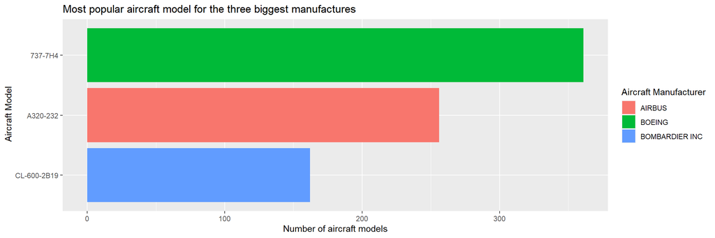

```
dat2 %>%
  group_by(plane_manufacturer) %>%
  distinct(tailnum, .keep_all = TRUE) %>%
  filter(plane_manufacturer %in% c("BOEING", "AIRBUS", "BOMBARDIER INC")) %>%
  count(plane_model) %>%
  slice_max(n) %>%
  ggplot(aes(reorder(plane_model, n), n, fill = plane_manufacturer)) +
  geom_col() +
  coord_flip() +
  labs(
    title = "Most popular aircraft model for the three biggest manufactures",
    x = " Aircraft Model",
    y = "Number of aircraft models",
    fill = "Aircraft Manufacturer"
  )
```

Boeing has the most popular aircraft model with their Boeing 737, followed by Airbus A320.

### What is the average distance pr. airline?

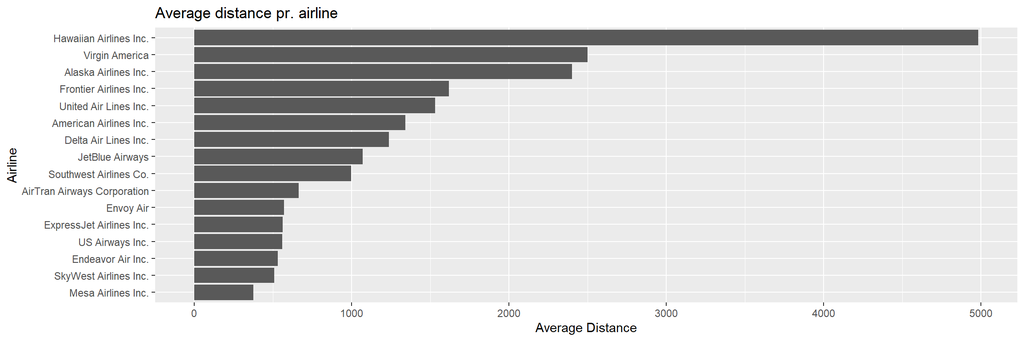

```
dat %>%
  group_by(carrier_name) %>%
  summarise(avg_distance = mean(distance)) %>%
  ggplot() +
  geom_col(aes(avg_distance, reorder(carrier_name, avg_distance))) +
  labs(
    title = "Average distance pr. airline",
    x = "Average Distance",
    y = "Airline"
  )
```

Interestingly we see that Hawaiian Airlines has the highest average flight distance, probably because of their location in the middle of the Pacific Ocean. Also Alaska Airlines is high on the list. We can also deduce that Mesa, SkyWest and Endeavor etc. are regional airlines as their average flight distance is fairly low.

## Colophon

This report has been created inside [RStudio](http://www.rstudio.com/ide/) using [R Markdown](https://rmarkdown.rstudio.com/) and the [distill](https://rstudio.github.io/distill/) format.

The report was built using:

```
 setting  value
 version  R version 4.0.3 (2020-10-10)
 os       Windows 10 x64
 system   x86_64, mingw32
 ui       RTerm
 language (EN)
 collate  Danish_Denmark.1252
 ctype    Danish_Denmark.1252
 tz       Europe/Paris
 date     2020-11-26
```